# Section 5: Medicare Advantage Quality and Regression Discontinuity

# Selecting “bin” width

1. Dummy variables: Create dummies for each bin, regress the outcome on the set of all dummies $R^{2}_{r}$, repeat with double the number of bins and find r-square value $R^{2}_{u}$, form F-stat, $\frac{R^{2}_{u}-R^{2}_{r}}{1-R^{2}_{u}}\times \frac{n-K-1}{K}$.
2. Interaction terms: Include interactions between dummies and the running variable, joint F-test for the interaction terms

If F-test suggests significance, then we have too few bins and need to narrow the bin width.

# Selecting bandwidth

In the RD case, we have two different mean-square error terms: 1. “From above”, $MSE_{+}(h) = E[(\hat{\mu}_{+}(c,h) - E[Y_{i}(1)|X_{i}=c])^2]$ 2. “From below”, $MSE_{-}(h) = E[(\hat{\mu}_{-}(c,h) - E[Y_{i}(0)|X_{i}=c])^2]$

–

Goal is to find $h$ that minimizes these values, but we don’t know the true $E[Y(1)|X=c]$ and $E[Y(0)|X=c]$. So we have two approaches: 1. Use **cross-validation** to choose $h$  
2. Explicitly solve for optimal bandwidth

# Back to simulated data

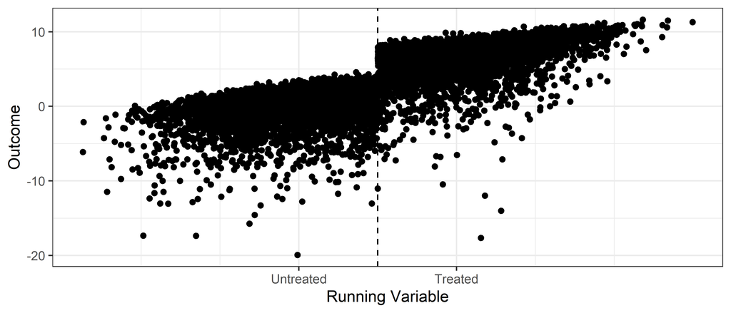

class: inverse, center, middle name: fuzzy_rd

# Fuzzy Regression Discontinuity

# Fuzzy RD is IV

In practice, fuzzy RD is employed as an instrumental variables estimator - Difference in outcomes among those above and below the discontinuity divided by the difference in treatment probabilities for those above and below the discontinuity,  
$E[Y_{i} | W_{i}=1] - E[Y_{i} | W_{i}=0] = \frac{E[Y_{i} | x_{i}\geq c] - E[Y_{i} | x_{i}< c]}{E[W_{i} | x_{i}\geq c] - E[W_{i} | x_{i}<c]}$ - Indicator for $x_{i}\geq c$ is an instrument for treatment status, $W_{i}$.

class: inverse, center, middle name: ma_data

# Full MA Data

```r
ma.data <- read_rds("D:/CloudStation/Professional/Research Projects/_Git/Medicare-Advantage/data/ma_data.rds")
```

# Clean the data

[output not shown]

# Calculate raw average rating

```r
ma.data.clean <- ma.data.clean %>%
  mutate(raw_rating=rowMeans(
    cbind(breastcancer_screen,rectalcancer_screen,cv_cholscreen,diabetes_cholscreen,
          glaucoma_test,monitoring,flu_vaccine,pn_vaccine,physical_health,
          mental_health,osteo_test,physical_monitor,primaryaccess,
          hospital_followup,depression_followup,nodelays,carequickly,
          overallrating_care,overallrating_plan,calltime,
          doctor_communicate,customer_service,osteo_manage,
          diabetes_eye,diabetes_kidney,diabetes_bloodsugar,
          diabetes_chol,antidepressant,bloodpressure,ra_manage,
          copd_test,betablocker,bladder,falling,appeals_timely,
          appeals_review),
    na.rm=T)) %>%
  select(contractid, planid, fips, avg_enrollment, first_enrollment,
         last_enrollment, state, county, raw_rating, partc_score,
         avg_eligibles, avg_enrolled, premium_partc, risk_ab, Star_Rating,
         bid, avg_ffscost, ma_rate)
```

class: inverse, center, middle name: insurance_stars

# Quality and Insurance Choice

# Distribution of star ratings

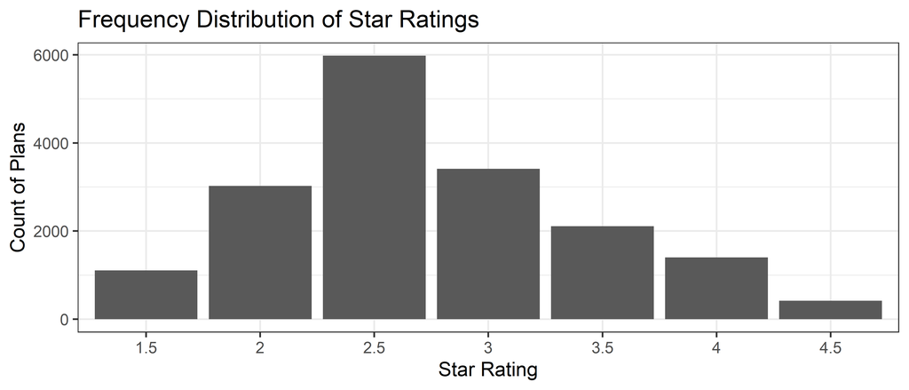

# Problems

- Certainly not the effect of a higher rating…
- Lots of things unobserved, like
  - actual quality
  - perceived quality
  - prices

# Note about scores

CMS does more than just an average… - variance across individual metrics - high variance is punished, low variance rewarded

# RD estimates

|  | Market Share |  |  |
| --- | --- | --- | --- |
|  | (1) | (2) | (3) |
| Raw Score |  | -0.044*** | -0.090*** |
|  |  | (0.009) | (0.011) |
| Treatment | 0.005*** | 0.009*** | 0.012*** |
|  | (0.0004) | (0.002) | (0.002) |
| Bandwith | 0.5 | 0.175 | 0.125 |
| Observations | 9,006 | 3,095 | 2,937 |
| *Note:* | p<0.1; p<0.05; p<0.01 |  |  |

# Built-in RD packages

```r
library(rdrobust)
rdplot(y=ma.rd1$mkt_share, x=ma.rd1$score, binselect="es", ci=95,
       title="RD Plot: Market Share", x.label="Summary Score",
       y.label="Market Share")
```

.plot-callout[

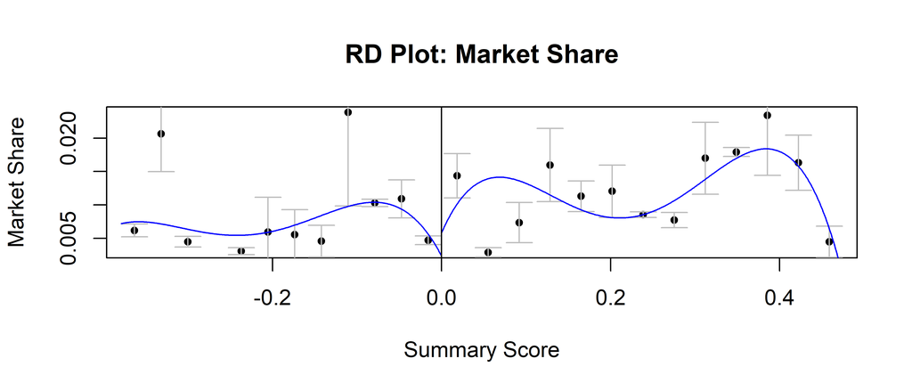

]

# Estimates from RD package

```r
est1 <- rdrobust(y=ma.rd1$mkt_share, x=ma.rd1$score)
summary(est1)
```

```
## Call: rdrobust
##
## Number of Obs.                 9006
## BW type                       mserd
## Kernel                   Triangular
## VCE method                       NN
##
## Number of Obs.                3024        5982
## Eff. Number of Obs.            275         136
## Order est. (p)                   1           1
## Order bias  (p)                  2           2
## BW est. (h)                  0.070       0.070
## BW bias (b)                  0.145       0.145
## rho (h/b)                    0.480       0.480
##
## =============================================================================
##         Method     Coef. Std. Err.         z     P>|z|      [ 95% C.I. ]
## =============================================================================
##   Conventional     0.031     0.006     4.727     0.000     [0.018 , 0.043]
##         Robust         -         -     4.706     0.000     [0.019 , 0.047]
## =============================================================================
```